# Simulation Analysis

Jeffrey Mei

2024-10-13

# Simulation Analysis

This document reads the simulation results file that is outputted by `cp_sim.R`. By consolidating all simulation results in a centralized location, we are able to efficiently retrieve past results and make comparisons.

**Tasks**:  
- [x] create more scenarios  
- [x] random change points, random means  
- [x] dense change points  
- [ ] play with parameters  
- [x] changing $n$  
- [ ] changing signal strength  
- [ ] changing penalty  
- [ ] generate more evaluation criteria  
- [x] `RandIndex`  
- [ ] F1 Score  
- [ ] try more methods  
- [x] PELT  
- [ ] binary segmentation  
- [ ] circular binary segmentation  
- [ ] wild binary segmentation  
- [ ] SaRa (create docker file)  
- [ ] 4S

**Glossary**:  
- `num_sims`: number of simulations  
- `sample_size`: sample sample_size  
- `scenario_num`: scenario number  
- `signal_strength`: magnitude of mean vector  
- `cp_method`: change point method (e.g. PELT)  
- `cp_penalty`: change point penalty  
- `cp_penalty_val`: change point penalty value  
- `eval_method`: evaluation method (e.g. Hausdorff)  
- `eval_value_mean`: mean of evaluation method  
- `eval_value_sd`: standard deviation of evaluation method  
- `eval_value_na`: number of NA values of evaluation method  
- `runtime`: runtime of change point method  
- `datetime`: date-time of export

## Scenarios

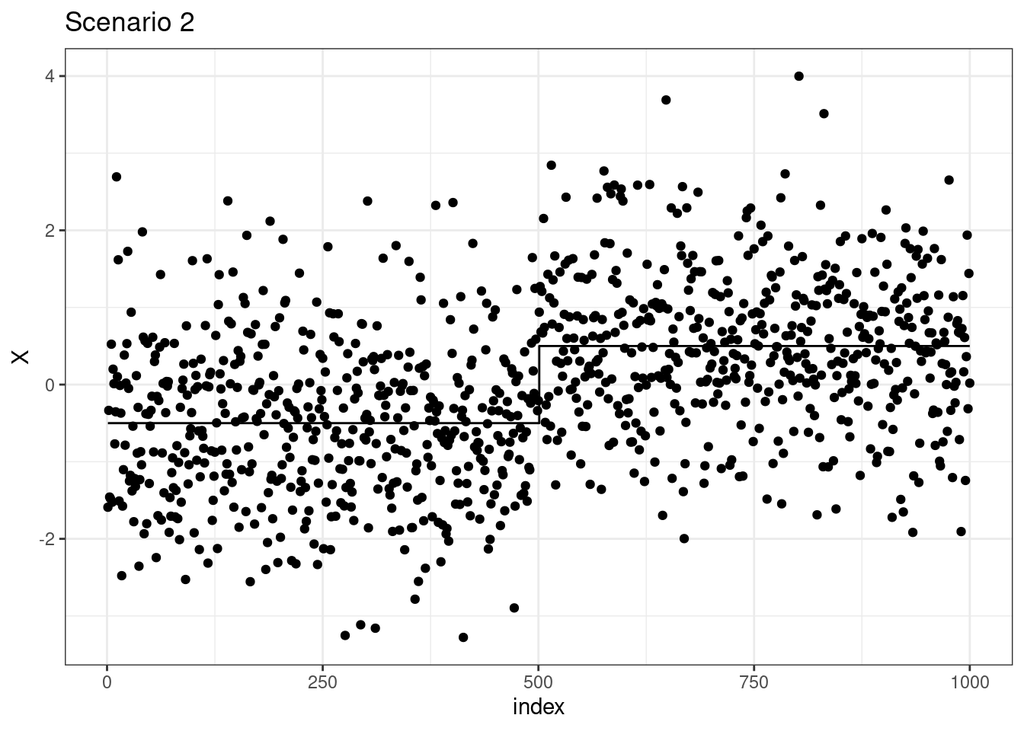

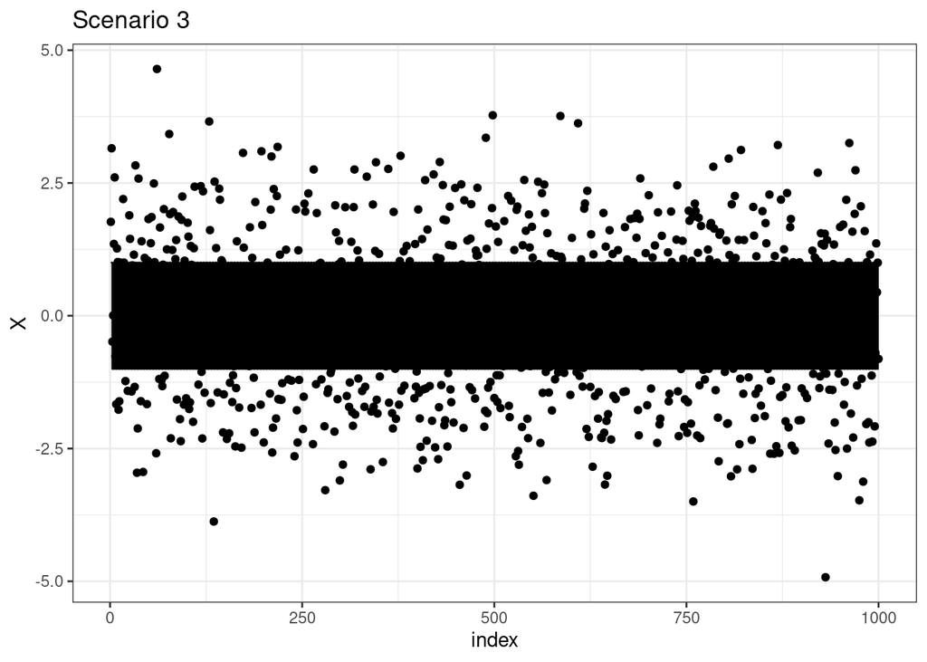

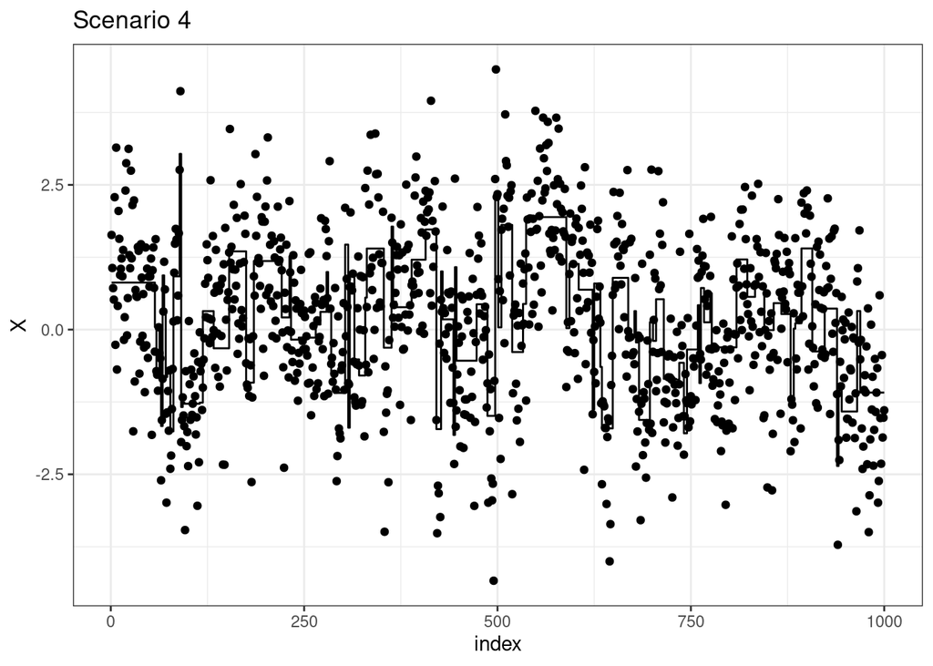

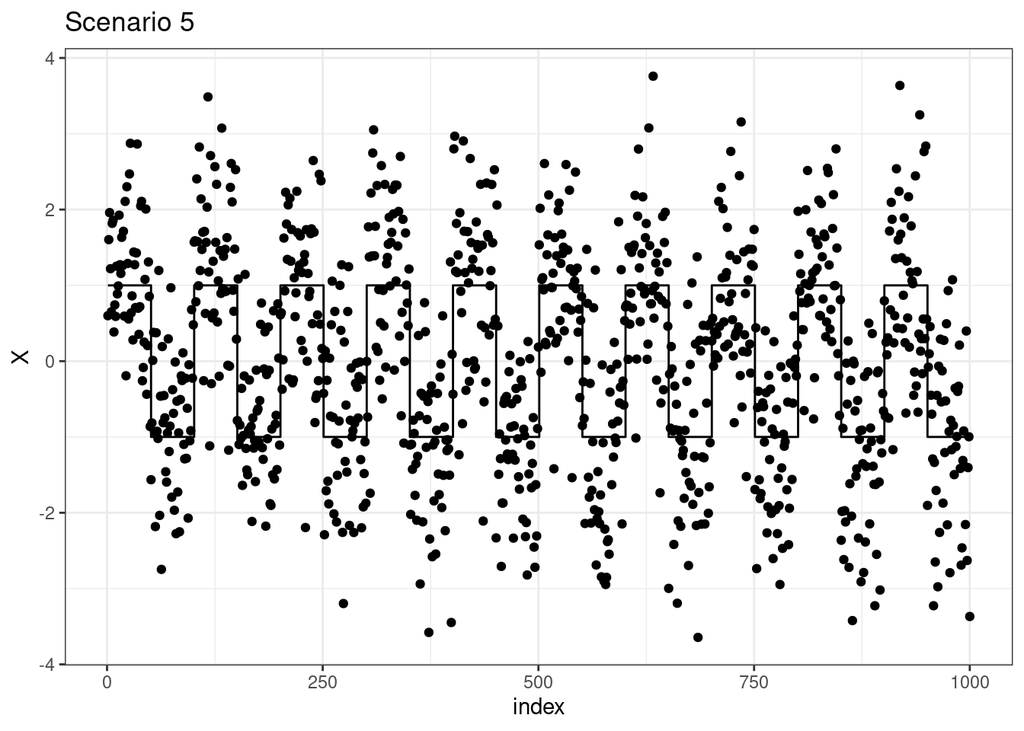

## PELT

**Sample Size vs Runtime**

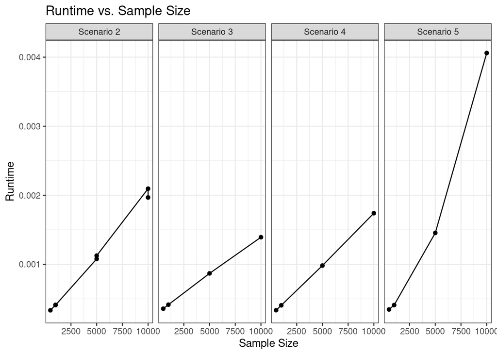

**Sample Size vs Accuracy**

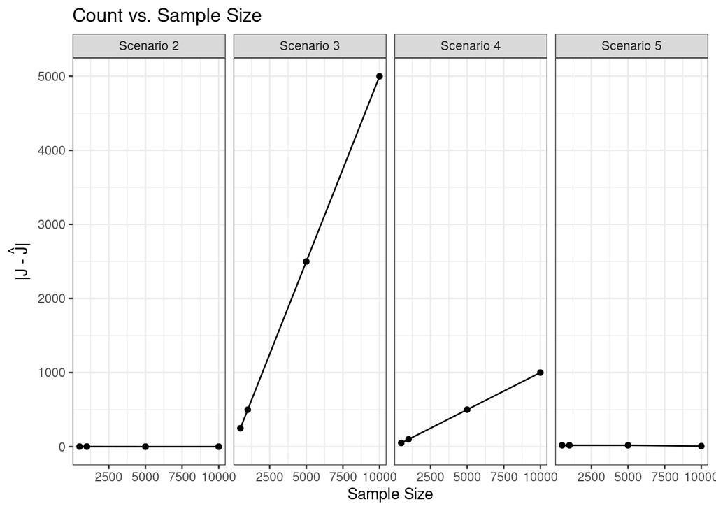

**Changing Signal Strength**

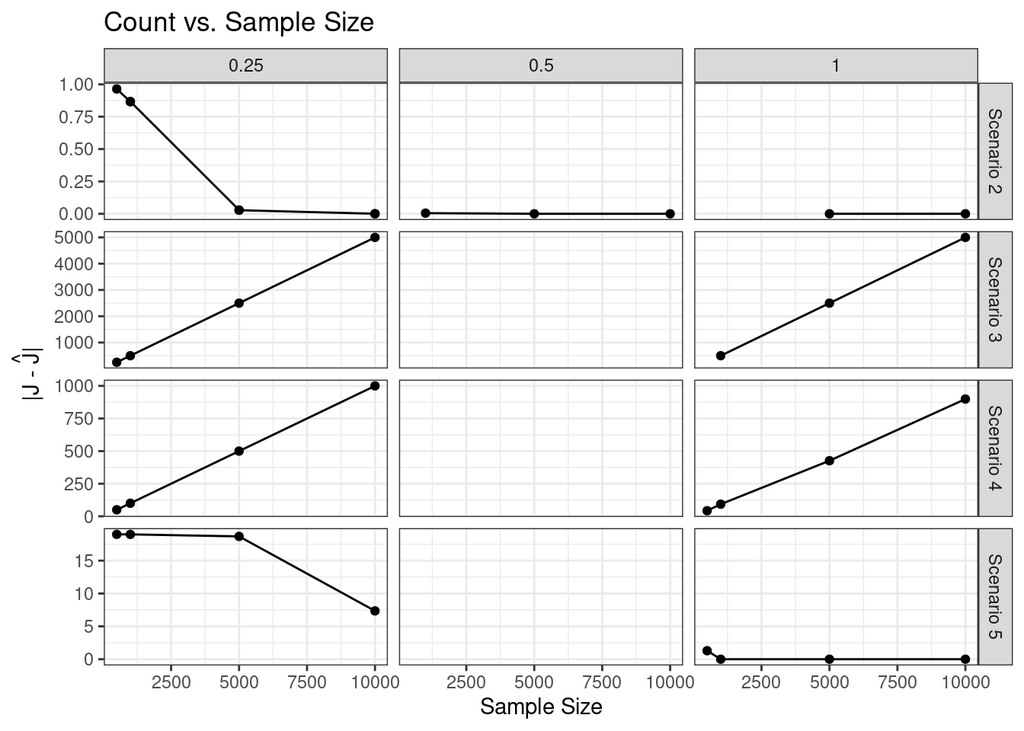